# Clients classification - bank marketing effectiveness

# Author: Adrian Żelazek

Introduction

1. Librarires
2. Dataset
3. Exploration Data Analysis (EDA) and visualizations
4. Analysis of normal distribution

   > 4.1 Verification based on statistical test and hypotheses  
   > 4.2 Verification based on kurtosis and skew  
   > 4.3 Verification based on distplots
5. Outliers removal
6. Dummying
7. Oversampling with SMOTE
8. Data selection with Recursive Feature Elimination (RFE)
9. Machine Learning Model - Logistic Regression

   > 9.1 Model building considering VIF

   > > 9.1.1 Checking of statistical significance of variables (p-value) in statsmodels  
   > > 9.1.2 VIF calculation  
   > > 9.1.3 Model building

   > > > 9.2 Model evaluation

   > > > > 9.2.1 Confusion matrix  
   > > > > 9.2.2 ROC curve  
   > > > > 9.2.3 AUC  
   > > > > 9.2.4 Accumulative protif curve  
   > > > > 9.2.5 Forecasting error of classes  
   > > > > 9.2.6 Classifivation report
10. Comparison of results on test and train datasets - overfitting/underfitting detection
11. Model interpretation
12. Results export to Excel
13. Conclusions

# Introduction

**The dataset description:**  
The data is related with direct marketing campaigns of a Portuguese banking institution. The marketing campaigns were based on phone calls. Often, more than one contact to the same client was required, in order to access if the product (bank term deposit) would be ('yes') or not ('no') subscribed.

Meaning of variables:

**bank client data:**  
1 - age (numeric)  
2 - job : type of job (categorical: 'admin.','blue-collar','entrepreneur','housemaid','management','retired','self-employed','services','student','technician','unemployed','unknown')  
3 - marital : marital status (categorical: 'divorced','married','single','unknown'; note: 'divorced' means divorced or widowed)  
4 - education (categorical: 'basic.4y','basic.6y','basic.9y','high.school','illiterate','professional.course','university.degree','unknown')  
5 - default: has credit in default? (categorical: 'no','yes','unknown')  
6 - housing: has housing loan? (categorical: 'no','yes','unknown')  
7 - loan: has personal loan? (categorical: 'no','yes','unknown')  
**related with the last contact of the current campaign:**  
8 - contact: contact communication type (categorical: 'cellular','telephone')  
9 - month: last contact month of year (categorical: 'jan', 'feb', 'mar', ..., 'nov', 'dec')  
10 - day_of_week: last contact day of the week (categorical: 'mon','tue','wed','thu','fri')  
11 - duration: last contact duration, in seconds (numeric). Important note: this attribute highly affects the output target  
(e.g., if duration=0 then y='no'). Yet, the duration is not known before a call is performed. Also, after the end of the call y is obviously known. Thus, this input should only be included for benchmark purposes and should be discarded if the intention is to have a realistic predictive model.  
**other attributes:**  
12 - campaign: number of contacts performed during this campaign and for this client (numeric, includes last contact)  
13 - pdays: number of days that passed by after the client was last contacted from a previous campaign (numeric; 999 means client was not previously contacted)  
14 - previous: number of contacts performed before this campaign and for this client (numeric)  
15 - poutcome: outcome of the previous marketing campaign (categorical: 'failure','nonexistent','success')  
**social and economic context attributes**  
16 - emp.var.rate: employment variation rate - quarterly indicator (numeric)  
17 - cons.price.idx: consumer price index - monthly indicator (numeric)  
18 - cons.conf.idx: consumer confidence index - monthly indicator (numeric)  
19 - euribor3m: euribor 3 month rate - daily indicator (numeric)  
20 - nr.employed: number of employees - quarterly indicator (numeric)  
**target variable**  
21 - y - has the client subscribed a term deposit? (binary: 'yes','no')

**Target variable:**  
1 - client bought term deposit  
0 - client did not bought term deposit

**Problem description:**  
Build and evaluate classification model to predict whether the client will subscribe to a term deposit.

**Programming language:**  
Python

**Libraries:**  
Scikit-learn, SciPy, Statsmodels, Pandas, NumPy, Matplotlib, Seaborn, Scikitplot, Yellowbrick

**Algorithms:**  
Notmal test, dummy coding, SMOTE, RFE, VIF, Logit, Logistic Regression

**Methods of model evaluation**  
Confusion Matrix, ROC curve, AUC, Accumulative protif curve, Forecasting error of classes, Classification Report and indicators: Accuracy, Recall, Precision, F1

# 1. Libraries

```python
#Libraries
import pandas as pd
import numpy as np

import matplotlib.pyplot as plt
import seaborn as sns
%matplotlib inline
import matplotlib.patches as mpatches

from sklearn.model_selection import train_test_split
from sklearn.linear_model import LogisticRegression
from sklearn.metrics import classification_report
from sklearn.metrics import confusion_matrix
from sklearn import metrics
from sklearn.metrics import roc_auc_score
import scipy.stats
from sklearn.feature_selection import RFE
from imblearn.over_sampling import SMOTE
from yellowbrick.classifier import ClassPredictionError
from yellowbrick.classifier import ClassificationReport
from yellowbrick.classifier import ROCAUC
import scikitplot as skplt
from statsmodels.stats.outliers_influence import variance_inflation_factor
import statsmodels.api as sm

import warnings
warnings.filterwarnings("ignore")
```

```python
#Version of Python and libraries used
from platform import python_version
import matplotlib
import sklearn
print("Python version is {}".format(python_version()))
print("Pandas version is {}".format(pd.__version__))
print("Scipy version is {}".format(scipy.__version__))
print("Scikit-learn is {}".format(sklearn.__version__))
print("Statsmodels is {}".format(sm.__version__))
print("Numpy version is {}".format(np.__version__))
print("Matplotlib version is {}".format(matplotlib.__version__))
print("Seaborn version is {}".format(sns.__version__))
```

```
Python version is 3.7.4
Pandas version is 0.25.1
Scipy version is 1.5.2
Scikit-learn is 0.23.2
Statsmodels is 0.10.1
Numpy version is 1.16.5
Matplotlib version is 3.1.2
Seaborn version is 0.9.0
```

```python
#Setting of plot style
plt.style.use('Solarize_Light2')
```

# 2. Dataset

```python
#Read of the dataset
data = pd.read_csv("bank_marketing_effectiveness.csv")
```

```python
#Start of the dataset
data.head(3)
```

|  | age | job | marital | education | default | housing | loan | contact | month | day_of_week | ... | campaign | pdays | previous | poutcome | emp_var_rate | cons_price_idx | cons_conf_idx | euribor3m | nr_employed | y |
| --- | --- | --- | --- | --- | --- | --- | --- | --- | --- | --- | --- | --- | --- | --- | --- | --- | --- | --- | --- | --- | --- |
| 0 | 44 | blue-collar | married | basic.4y | unknown | yes | no | cellular | aug | thu | ... | 1 | 999 | 0 | nonexistent | 1.4 | 93.444 | -36.1 | 4.963 | 5228.1 | 0 |
| 1 | 53 | technician | married | unknown | no | no | no | cellular | nov | fri | ... | 1 | 999 | 0 | nonexistent | -0.1 | 93.200 | -42.0 | 4.021 | 5195.8 | 0 |
| 2 | 28 | management | single | university.degree | no | yes | no | cellular | jun | thu | ... | 3 | 6 | 2 | success | -1.7 | 94.055 | -39.8 | 0.729 | 4991.6 | 1 |

3 rows × 21 columns

```python
#End of the dataset
data.tail(3)
```

|  | age | job | marital | education | default | housing | loan | contact | month | day_of_week | ... | campaign | pdays | previous | poutcome | emp_var_rate | cons_price_idx | cons_conf_idx | euribor3m | nr_employed | y |
| --- | --- | --- | --- | --- | --- | --- | --- | --- | --- | --- | --- | --- | --- | --- | --- | --- | --- | --- | --- | --- | --- |
| 41185 | 42 | admin. | single | university.degree | unknown | yes | yes | telephone | may | wed | ... | 3 | 999 | 0 | nonexistent | 1.1 | 93.994 | -36.4 | 4.857 | 5191.0 | 0 |
| 41186 | 48 | technician | married | professional.course | no | no | yes | telephone | oct | tue | ... | 2 | 999 | 0 | nonexistent | -3.4 | 92.431 | -26.9 | 0.742 | 5017.5 | 0 |
| 41187 | 25 | student | single | high.school | no | no | no | telephone | may | fri | ... | 4 | 999 | 0 | nonexistent | 1.1 | 93.994 | -36.4 | 4.859 | 5191.0 | 0 |

3 rows × 21 columns

```python
#Dataset description
print("Dataset contains {} observations as well as {} variables.""\n""The are the following list of variables in the dataset:{}"
      .format(data.shape[0], data.shape[1], list(data.columns)))
```

```
Dataset contains 41188 observations as well as 21 variables.
The are the following list of variables in the dataset:['age', 'job', 'marital', 'education', 'default', 'housing', 'loan', 'contact', 'month', 'day_of_week', 'duration', 'campaign', 'pdays', 'previous', 'poutcome', 'emp_var_rate', 'cons_price_idx', 'cons_conf_idx', 'euribor3m', 'nr_employed', 'y']
```

```python
#Survey of the overall data structure
datasetSummary = pd.DataFrame(data.dtypes, columns=["Data type"])
datasetSummary["is NaN"] = pd.DataFrame(data.isna().any())
datasetSummary["Sum of NaN"] = pd.DataFrame(data.isna().sum())
datasetSummary["Percent of NaN"] = round((data.apply(pd.isna).mean()*100),2)
datasetSummary["Data type"] = datasetSummary["Data type"].astype(str)
datasetSummary
```

|  | Data type | is NaN | Sum of NaN | Percent of NaN |
| --- | --- | --- | --- | --- |
| age | int64 | False | 0 | 0.0 |
| job | object | False | 0 | 0.0 |
| marital | object | False | 0 | 0.0 |
| education | object | False | 0 | 0.0 |
| default | object | False | 0 | 0.0 |
| housing | object | False | 0 | 0.0 |
| loan | object | False | 0 | 0.0 |
| contact | object | False | 0 | 0.0 |
| month | object | False | 0 | 0.0 |
| day_of_week | object | False | 0 | 0.0 |
| duration | int64 | False | 0 | 0.0 |
| campaign | int64 | False | 0 | 0.0 |
| pdays | int64 | False | 0 | 0.0 |
| previous | int64 | False | 0 | 0.0 |
| poutcome | object | False | 0 | 0.0 |
| emp_var_rate | float64 | False | 0 | 0.0 |
| cons_price_idx | float64 | False | 0 | 0.0 |
| cons_conf_idx | float64 | False | 0 | 0.0 |
| euribor3m | float64 | False | 0 | 0.0 |
| nr_employed | float64 | False | 0 | 0.0 |
| y | int64 | False | 0 | 0.0 |

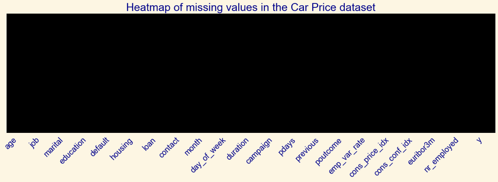

```python
#Heatmap of missing values
#Size of the plot
plt.figure(figsize=(20,5))

#Creation of the heatmap
sns.heatmap(data.isnull(),
            yticklabels=False,
            cbar=False,
            cmap="bone").set_title("Heatmap of missing values in the Car Price dataset",
                                   fontsize = 25,
                                   color = "darkblue")

#X-axis descriptions in terms of rotation and size of caption
plt.xticks(rotation=45, fontsize=18, horizontalalignment="right", color="darkblue")
plt.show()
```

```python
#Categories in "education" variable
data["education"].unique()
```

```
array(['basic.4y', 'unknown', 'university.degree', 'high.school',
       'basic.9y', 'professional.course', 'basic.6y', 'illiterate'],
      dtype=object)
```

```python
data["education"]=np.where(data["education"] =="basic.9y", "basic", data["education"])
data["education"]=np.where(data["education"] =="basic.6y", "basic", data["education"])
data["education"]=np.where(data["education"] =="basic.4y", "basic", data["education"])
```

```python
#Categories in "education" variable after modification
data["education"].unique()
```

```
array(['basic', 'unknown', 'university.degree', 'high.school',
       'professional.course', 'illiterate'], dtype=object)
```

# 3. Exploration Data Analysis (EDA) and visualizations

- Classes are imbalanced, and the ratio of no-subscription to subscription instances is 88.7% to 11.3%.
- The frequency of purchase of the deposit depends a great deal on the job title. Thus, the job title can be a good predictor of the outcome variable.
- The marital status does not seem a strong predictor for the outcome variable.
- Education seems a good predictor of the outcome variable.
- Day of week may not be a good predictor of the outcome.
- Month might be a good predictor of the outcome variable.
- Most of the customers of the bank in this dataset are in the age range of 30–40.
- Poutcome seems to be a good predictor of the outcome variable.

### Target variable - y

Classes are imbalanced and the ratio of no-subscription to subscription instances is 88.7% to 11.3%.

```python
#Distribution of default (target variable) in percent in the dataset
default_percent_dist = data["y"].value_counts(normalize=True).round(3).to_frame()*100
default_percent_dist["y distribution"] = data["y"].value_counts().round(3).to_frame()
default_percent_dist.columns=["y distribution in %", "y distribution"]
default_percent_dist
```

|  | y distribution in % | y distribution |
| --- | --- | --- |
| 0 | 88.7 | 36548 |
| 1 | 11.3 | 4640 |

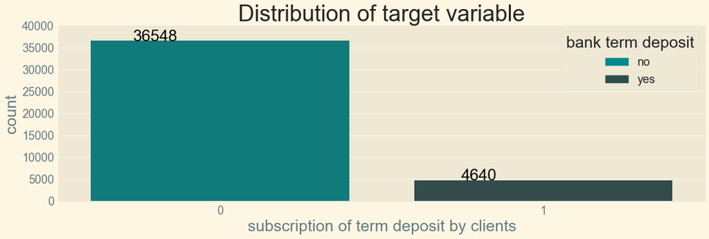

```python
#Distribution of default
plt.figure(figsize=(18, 5))
ax=sns.countplot(x="y",
                 data=data,
                 palette = ["darkcyan", "darkslategray"])
ax.set_title("Distribution of target variable", fontsize=35)
plt.xlabel("subscription of term deposit by clients",fontsize=25)
plt.ylabel("count", fontsize=25)
plt.xticks(fontsize=18)
plt.yticks(fontsize=18)
ax.set(ylim=(0, 40000))
for p in ax.patches:
    ax.annotate(f'\n{p.get_height()}',
                (p.get_x()+0.2,
                 p.get_height()),
                ha="center",
                color="black",
                size=25)

#Settings of legend
darkcyan_patch = mpatches.Patch(color="darkcyan", label= "no")
darkslategray_patch = mpatches.Patch(color="darkslategray", label= "yes")
plt.legend(handles=[darkcyan_patch,
                    darkslategray_patch],
           loc="best",
           prop={"size": 18},
           title="bank term deposit",
           title_fontsize="25",
           frameon=True)

plt.show()
```

```python
#Mean values of each numerical variable for target variable
data.groupby("y").mean()
```

| y | age | duration | campaign | pdays | previous | emp_var_rate | cons_price_idx | cons_conf_idx | euribor3m | nr_employed |
| --- | --- | --- | --- | --- | --- | --- | --- | --- | --- | --- |
| 0 | 39.911185 | 220.844807 | 2.633085 | 984.113878 | 0.132374 | 0.248875 | 93.603757 | -40.593097 | 3.811491 | 5176.166600 |
| 1 | 40.913147 | 553.191164 | 2.051724 | 792.035560 | 0.492672 | -1.233448 | 93.354386 | -39.789784 | 2.123135 | 5095.115991 |

### job

Job title can be a good predictor of the outcome variable because it is characterized by a high volatility of values.

```python
#Distribution of default (target variable) in percent in the dataset
default_percent_dist = data["job"].value_counts(normalize=True).round(3).to_frame()*100
default_percent_dist["job distribution"] = data["job"].value_counts().round(3).to_frame()
default_percent_dist.columns=["job distribution in %", "job distribution"]
default_percent_dist
```

|  | job distribution in % | job distribution |
| --- | --- | --- |
| admin. | 25.3 | 10422 |
| blue-collar | 22.5 | 9254 |
| technician | 16.4 | 6743 |
| services | 9.6 | 3969 |
| management | 7.1 | 2924 |
| retired | 4.2 | 1720 |
| entrepreneur | 3.5 | 1456 |
| self-employed | 3.5 | 1421 |
| housemaid | 2.6 | 1060 |
| unemployed | 2.5 | 1014 |
| student | 2.1 | 875 |
| unknown | 0.8 | 330 |

People working as: admin definitely the most offen bought bank term deposit. What is understood the least interested were people housemaid. What is interesting people who run their business also were not interested in deposit. Probably their have other way to invest money.

```python
#Crosstab of the most frequently bought deposit based on job
pd.crosstab(data["job"], data["y"]).sort_values(by=1, ascending=False).T
```

| job y | admin. | technician | blue-collar | retired | management | services | student | self-employed | unemployed | entrepreneur | housemaid | unknown |
| --- | --- | --- | --- | --- | --- | --- | --- | --- | --- | --- | --- | --- |
| 0 | 9070 | 6013 | 8616 | 1286 | 2596 | 3646 | 600 | 1272 | 870 | 1332 | 954 | 293 |
| 1 | 1352 | 730 | 638 | 434 | 328 | 323 | 275 | 149 | 144 | 124 | 106 | 37 |

[figure not shown]

```python
#Plot of purchase of deposit based on job
crosstab_job_y=pd.crosstab(data["job"], data["y"])

crosstab_job_y.div(crosstab_job_y.sum(1).astype(float), axis=0).plot(kind="bar",
                                                                     figsize=(18,5),
                                                                     stacked=True,
                                                                     cmap="Dark2")
plt.title("Purchase frequency based on job", fontsize=35)
plt.xlabel("Job", fontsize=25)
plt.ylabel("Proportion of customers", fontsize=25)
plt.xticks(fontsize=18, rotation=45)
plt.yticks(fontsize=18)

#Settings of legend
plt.legend(loc="best",
           prop={"size": 15},
           title="bank term deposit",
           title_fontsize="18",
           frameon=True)

plt.show()
```

### martial status

```python
#Distribution of default (target variable) in percent in the dataset
default_percent_dist = data["marital"].value_counts(normalize=True).round(3).to_frame()*100
default_percent_dist["marital distribution"] = data["marital"].value_counts().round(3).to_frame()
default_percent_dist.columns=["marital distribution in %", "marital distribution"]
default_percent_dist
```

|  | marital distribution in % | marital distribution |
| --- | --- | --- |
| married | 60.5 | 24928 |
| single | 28.1 | 11568 |
| divorced | 11.2 | 4612 |
| unknown | 0.2 | 80 |

Married and single people the most offen bought bank term deposit. Definitely less interested in term deposit are divorced people.

```python
#Crosstab of the most frequently bought deposit based on martial status
pd.crosstab(data["marital"], data["y"]).sort_values(by=1, ascending=False).T
```

| marital y | married | single | divorced | unknown |
| --- | --- | --- | --- | --- |
| 0 | 22396 | 9948 | 4136 | 68 |
| 1 | 2532 | 1620 | 476 | 12 |

[figure not shown]

```python
crosstab_marital_y=pd.crosstab(data["marital"], data["y"])

crosstab_marital_y.div(crosstab_marital_y.sum(1).astype(float), axis=0).plot(kind="bar",
                                                                             stacked=True,
                                                                             figsize=(18,5),
                                                                             cmap="GnBu")
plt.title("Purchase frequency based on marital status", fontsize=35)
plt.xlabel("Marital status", fontsize = 25)
plt.ylabel("Proportion of customers", fontsize=25)
plt.xticks(fontsize=18, rotation=45)
plt.yticks(fontsize=18)

#Settings of legend
plt.legend(loc="best",
           prop={"size": 15},
           title="bank term deposit",
           title_fontsize="18",
           frameon=True)

plt.show()
```

### education

Education seems a good predictor of the outcome variable because it is characterized by a high volatility of values."

```python
#Distribution of default (target variable) in percent in the dataset
default_percent_dist = data["education"].value_counts(normalize=True).round(3).to_frame()*100
default_percent_dist["education distribution"] = data["education"].value_counts().round(3).to_frame()
default_percent_dist.columns=["education distribution in %", "education distribution"]
default_percent_dist
```

|  | education distribution in % | education distribution |
| --- | --- | --- |
| basic | 30.4 | 12513 |
| university.degree | 29.5 | 12168 |
| high.school | 23.1 | 9515 |
| professional.course | 12.7 | 5243 |
| unknown | 4.2 | 1731 |
| illiterate | 0.0 | 18 |

People with university degree definitely the most offen bought bank term deposit.

```python
#Crosstab of the most frequently bought deposit based on education
pd.crosstab(data["education"], data["y"]).sort_values(by=1, ascending=False).T
```

| education y | university.degree | basic | high.school | professional.course | unknown | illiterate |
| --- | --- | --- | --- | --- | --- | --- |
| 0 | 10498 | 11424 | 8484 | 4648 | 1480 | 14 |
| 1 | 1670 | 1089 | 1031 | 595 | 251 | 4 |

[figure not shown]

```python
crosstab_education_y=pd.crosstab(data.education,data.y)

crosstab_education_y.div(crosstab_education_y.sum(1).astype(float), axis=0).plot(kind="bar",
                                                                                 stacked=True,
                                                                                 figsize=(18,5),
                                                                                 cmap="Pastel2_r")

plt.title("Purchase frequency based on education level", fontsize=35)
plt.xlabel("education", fontsize=25)
plt.ylabel("Proportion of customers", fontsize=25)
plt.xticks(fontsize=18, rotation=45)
plt.yticks(fontsize=18)

#Settings of legend
plt.legend(loc="best",
           prop={"size": 15},
           title="bank term deposit",
           title_fontsize="18",
           frameon=True)

plt.show()
```

### day of week

Day of week may not be a good predictor of the outcome because it is not characterized by a high volatility of values.

```python
#Distribution of default (target variable) in percent in the dataset
default_percent_dist = data["day_of_week"].value_counts(normalize=True).round(3).to_frame()*100
default_percent_dist["day_of_week distribution"] = data["day_of_week"].value_counts().round(3).to_frame()
default_percent_dist.columns=["day_of_week distribution in %", "day_of_week distribution"]
default_percent_dist
```

|  | day_of_week distribution in % | day_of_week distribution |
| --- | --- | --- |
| thu | 20.9 | 8623 |
| mon | 20.7 | 8514 |
| wed | 19.7 | 8134 |
| tue | 19.6 | 8090 |
| fri | 19.0 | 7827 |

```python
#Crosstab of the most frequently bought deposit based on day of week
pd.crosstab(data["day_of_week"], data["y"]).sort_values(by=1, ascending=False).T
```

| day_of_week y | thu | tue | wed | mon | fri |
| --- | --- | --- | --- | --- | --- |
| 0 | 7578 | 7137 | 7185 | 7667 | 6981 |
| 1 | 1045 | 953 | 949 | 847 | 846 |

[figure not shown]

```python
crosstab_dow_y=pd.crosstab(data.day_of_week,data.y)

crosstab_dow_y.div(crosstab_dow_y.sum(1).astype(float), axis=0).plot(kind="bar",
                                                                     stacked=True,
                                                                     figsize=(18,5),
                                                                     cmap="YlOrRd")

plt.title("Purchase frequency based on day of week", fontsize=35)
plt.xlabel("day of Week", fontsize=25)
plt.ylabel("Proportion of customers", fontsize=25)
plt.xticks(fontsize=18, rotation=45)
plt.yticks(fontsize=18)

#Settings of legend
plt.legend(loc="best",
           prop={"size": 15},
           title="bank term deposit",
           title_fontsize="18",
           frameon=True)

plt.show()
```

### month

Month might be a good predictor of the outcome variable because it is characterized by a high volatility of values."

```python
#Distribution of default (target variable) in percent in the dataset
default_percent_dist = data["month"].value_counts(normalize=True).round(3).to_frame()*100
default_percent_dist["month distribution"] = data["month"].value_counts().round(3).to_frame()
default_percent_dist.columns=["month distribution in %", "month distribution"]
default_percent_dist
```

|  | month distribution in % | month distribution |
| --- | --- | --- |
| may | 33.4 | 13769 |
| jul | 17.4 | 7174 |
| aug | 15.0 | 6178 |
| jun | 12.9 | 5318 |
| nov | 10.0 | 4101 |
| apr | 6.4 | 2632 |
| oct | 1.7 | 718 |
| sep | 1.4 | 570 |
| mar | 1.3 | 546 |
| dec | 0.4 | 182 |

```python
#Crosstab of the most frequently bought deposit based on month
pd.crosstab(data["month"], data["y"]).sort_values(by=1, ascending=False).T
```

| month y | may | aug | jul | jun | apr | nov | oct | mar | sep | dec |
| --- | --- | --- | --- | --- | --- | --- | --- | --- | --- | --- |
| 0 | 12883 | 5523 | 6525 | 4759 | 2093 | 3685 | 403 | 270 | 314 | 93 |
| 1 | 886 | 655 | 649 | 559 | 539 | 416 | 315 | 276 | 256 | 89 |

[figure not shown]

```python
crosstab_month_y=pd.crosstab(data.month,data.y)

crosstab_month_y.div(crosstab_month_y.sum(1).astype(float), axis=0).plot(kind="bar",
                                                                         stacked=True,
                                                                         figsize=(18,5),
                                                                         cmap="Spectral")

plt.title("Purchase frequency based on month", fontsize=35)
plt.xlabel("month", fontsize=25)
plt.ylabel("Proportion of customers", fontsize=25)
plt.xticks(fontsize=18, rotation=45)
plt.yticks(fontsize=18)

#Settings of legend
plt.legend(loc="best",
           prop={"size": 15},
           title="bank term deposit",
           title_fontsize="18",
           frameon=True)

plt.show()
```

### age

Most of the customers in this dataset are in the age range of 30–40. The most of the respondents are 31 years old.

```python
#Distribution of default (target variable) in percent in the dataset
default_percent_dist = data["age"].value_counts(normalize=True).round(3).to_frame()*100
default_percent_dist["age distribution"] = data["age"].value_counts().round(3).to_frame()
default_percent_dist.columns=["age distribution in %", "age distribution"]
default_percent_dist.sort_values(by="age distribution", ascending=False).head(5)
```

|  | age distribution in % | age distribution |
| --- | --- | --- |
| 31 | 4.7 | 1947 |
| 32 | 4.5 | 1846 |
| 33 | 4.5 | 1833 |
| 36 | 4.3 | 1780 |
| 35 | 4.3 | 1759 |

People aged around 30 are most interested in bank term deposit. Teenagers and people of student age are the least interested.

```python
#Crosstab of the most frequently bought deposit based on age
pd.crosstab(data["age"], data["y"]).sort_values(by=1, ascending=False).T
```

| age y | 31 | 33 | 30 | 29 | 34 | 32 | 35 | 36 | 28 | 38 | ... | 86 | 84 | 92 | 89 | 17 | 98 | 87 | 91 | 94 | 95 |
| --- | --- | --- | --- | --- | --- | --- | --- | --- | --- | --- | --- | --- | --- | --- | --- | --- | --- | --- | --- | --- | --- |
| 0 | 1727 | 1623 | 1512 | 1267 | 1561 | 1662 | 1592 | 1626 | 850 | 1264 | ... | 3 | 4 | 1 | 0 | 3 | 0 | 0 | 2 | 1 | 1 |
| 1 | 220 | 210 | 202 | 186 | 184 | 184 | 167 | 154 | 151 | 143 | ... | 5 | 3 | 3 | 2 | 2 | 2 | 1 | 0 | 0 | 0 |

2 rows × 78 columns

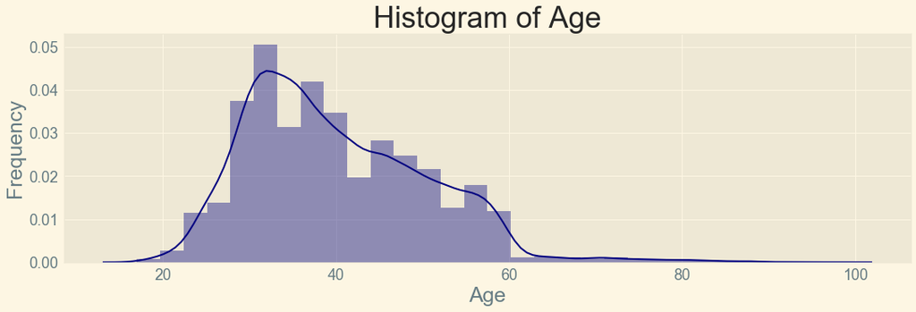

```python
plt.figure(figsize=(18, 5))
sns.distplot(data["age"],
             bins=30,
             color="navy",
             kde=True)
plt.title("Histogram of Age", fontsize=35)
plt.xlabel("Age", fontsize=25)
plt.ylabel("Frequency", fontsize=25)
plt.xticks(fontsize=18)
plt.yticks(fontsize=18)

plt.show()
```

### poutcome

Poutcome seems to be a good predictor of the outcome variable because it is characterized by a high volatility of values.

```python
#Distribution of default (target variable) in percent in the dataset
default_percent_dist = data["poutcome"].value_counts(normalize=True).round(3).to_frame()*100
default_percent_dist["poutcome distribution"] = data["poutcome"].value_counts().round(3).to_frame()
default_percent_dist.columns=["poutcome distribution in %", "poutcome distribution"]
default_percent_dist
```

|  | poutcome distribution in % | poutcome distribution |
| --- | --- | --- |
| nonexistent | 86.3 | 35563 |
| failure | 10.3 | 4252 |
| success | 3.3 | 1373 |

***Most of analysed customers come from the category "nonexistent" means that company has to thoroughly analyze and change hours of contact with clients via call center. Moreover, a lot of previous contacts were failure compared to success. It is advisable to additionally motivate employees or organize additional training to increase their effectiveness of sales.

```python
#Crosstab of the most frequently bought deposit based on outcome of the previous marketing campaign
pd.crosstab(data["poutcome"], data["y"]).sort_values(by=1, ascending=False).T
```

| poutcome y | nonexistent | success | failure |
| --- | --- | --- | --- |
| 0 | 32422 | 479 | 3647 |
| 1 | 3141 | 894 | 605 |

[figure not shown]

```python
crosstab_poutcome=pd.crosstab(data.poutcome,data.y)

crosstab_poutcome.div(crosstab_poutcome.sum(1).astype(float), axis=0).plot(kind="bar",
                                                                                 stacked=True,
                                                                                 figsize=(18,5),
                                                                                 cmap="cividis_r")

plt.title("Purchase frequency based on poutcome", fontsize=35)
plt.xlabel("poutcome", fontsize=25)
plt.ylabel("Proportion of customers", fontsize=25)
plt.xticks(fontsize=18, rotation=45)
plt.yticks(fontsize=18)

#Settings of legend
plt.legend(loc="best",
           prop={"size": 15},
           title="bank term deposit",
           title_fontsize="18",
           frameon=True)

plt.show()
```

# 4. Analysis of normal distribution

This function tests the null hypothesis that a sample comes from a normal distribution. For variables with p_value > alpha variable takes a normal distribution.

H0 = the variable comes from a normal distribution  
H1 = the variable does not come from a normal distribution

Adopted materiality level alpha = 0.05  
No variable comes from a normal distribution.

### 4.1 Verification based on statistical test and hypotheses

```python
#Select numerical variables from the dataset
data_numerical = data[["age", "duration", "campaign", "pdays", "previous",
                       "emp_var_rate", "cons_price_idx", "cons_conf_idx",
                       "euribor3m", "nr_employed"]]
#Verification of hypotheses
results = []
for feature in data_numerical.columns:
    alpha = 0.05
    p_value = scipy.stats.normaltest(data_numerical[feature])[1]
    results.append([feature, p_value])
    if(p_value < alpha):
        print("For variable \"" + feature +
              "\" I reject the zero hypothesis.\n The variable DOES NOT HAVE normal distribution. P-value:", p_value)
    else:
        print("For variable \"" + feature +
              "\" no grounds for rejecting the zero hypothesis have been detected. The variable HAS normal distribution. P-value:", p_value)
```

```
For variable "age" I reject the zero hypothesis.
 The variable DOES NOT HAVE normal distribution. P-value: 0.0
For variable "duration" I reject the zero hypothesis.
 The variable DOES NOT HAVE normal distribution. P-value: 0.0
For variable "campaign" I reject the zero hypothesis.
 The variable DOES NOT HAVE normal distribution. P-value: 0.0
For variable "pdays" I reject the zero hypothesis.
 The variable DOES NOT HAVE normal distribution. P-value: 0.0
For variable "previous" I reject the zero hypothesis.
 The variable DOES NOT HAVE normal distribution. P-value: 0.0
For variable "emp_var_rate" I reject the zero hypothesis.
 The variable DOES NOT HAVE normal distribution. P-value: 0.0
For variable "cons_price_idx" I reject the zero hypothesis.
 The variable DOES NOT HAVE normal distribution. P-value: 0.0
For variable "cons_conf_idx" I reject the zero hypothesis.
 The variable DOES NOT HAVE normal distribution. P-value: 4.666821377644087e-204
For variable "euribor3m" I reject the zero hypothesis.
 The variable DOES NOT HAVE normal distribution. P-value: 0.0
For variable "nr_employed" I reject the zero hypothesis.
 The variable DOES NOT HAVE normal distribution. P-value: 0.0
```

```python
#Summary of analysis of normal distribution based on p-value
summary_normal_distribution = pd.DataFrame(results)
summary_normal_distribution.columns = ["variable", "p-value"]
summary_normal_distribution.set_index("variable", inplace = True)
summary_normal_distribution.sort_values("p-value", ascending = False, inplace = True)
summary_normal_distribution.T
```

| variable | cons_conf_idx | age | duration | campaign | pdays | previous | emp_var_rate | cons_price_idx | euribor3m | nr_employed |
| --- | --- | --- | --- | --- | --- | --- | --- | --- | --- | --- |
| p-value | 4.666821e-204 | 0.0 | 0.0 | 0.0 | 0.0 | 0.0 | 0.0 | 0.0 | 0.0 | 0.0 |

### 4.2 Verification based on kurtosis and skew

Normal distribution parameters should be:

- kurtosis = 0
- skew = 0

Kurtosis is a measure of flattening the decomposition. It tells how flattened (negative values of kurtosis) or bloated (positive values of kurtosis) the distribution of the examined variable is in relation to normal distribution.

Interpretation of skew:

- A factor of 0 is a symmetrical distribution.
- A negative coefficient is a left-sided oblique distribution (elongated left arm of the distribution; mean less than the median).
- A factor with a positive value is a right-hand slanted distribution (elongated right arm of the distribution; mean greater than the median).

```python
#Calculation of kurtosis and skew for each numerical variables by aggregation method
data_numerical.agg(["kurtosis", "skew"])
```

|  | age | duration | campaign | pdays | previous | emp_var_rate | cons_price_idx | cons_conf_idx | euribor3m | nr_employed |
| --- | --- | --- | --- | --- | --- | --- | --- | --- | --- | --- |
| kurtosis | 0.791312 | 20.247938 | 36.979795 | 22.229463 | 20.108816 | -1.062632 | -0.829809 | -0.358558 | -1.406803 | -0.003760 |
| skew | 0.784697 | 3.263141 | 4.762507 | -4.922190 | 3.832042 | -0.724096 | -0.230888 | 0.303180 | -0.709188 | -1.044262 |

According to the assumptions of normal distribution, the mean value and the median should be very close (preferably equal) to each other. Then there is a chance to suspect the distribution of the variable of lack of diagonality.

Differences in values show that distribution is skewed:

- mean < median --> left oblique distribution (elongated left arm of distribution)
- mean > median --> right oblique distribution (elongated right arm of distribution)

```python
#Calculation of mean and median for each numerical variables by aggregation method
data_numerical.agg(["mean", "median"])
```

|  | age | duration | campaign | pdays | previous | emp_var_rate | cons_price_idx | cons_conf_idx | euribor3m | nr_employed |
| --- | --- | --- | --- | --- | --- | --- | --- | --- | --- | --- |
| mean | 40.02406 | 258.28501 | 2.567593 | 962.475454 | 0.172963 | 0.081886 | 93.575664 | -40.5026 | 3.621291 | 5167.035911 |
| median | 38.00000 | 180.00000 | 2.000000 | 999.000000 | 0.000000 | 1.100000 | 93.749000 | -41.8000 | 4.857000 | 5191.000000 |

### 4.3 Verification based on distplots

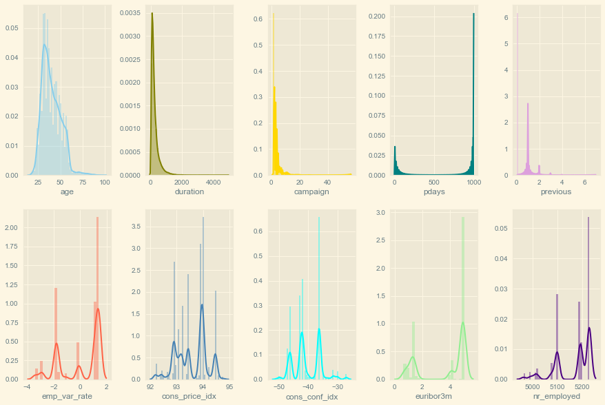

```python
#Distplots of each numerical variable
def create_hists(kde=True):
    """
    Creation of distplots for numerical variables in the dataset.
    Parameter kde = True for line of trend.
    """
    f, axes = plt.subplots(2, 5,figsize=(15,10), sharex=False)
    plt.subplots_adjust(left=None, bottom=None, right=None, top=None, wspace=0.4, hspace=0.2)
    sns.distplot(data["age"], color="skyblue", ax=axes[0, 0],kde=kde)
    sns.distplot(data["duration"], color="olive", ax=axes[0, 1],kde=kde)
    sns.distplot(data["campaign"], color="gold", ax=axes[0, 2],kde=kde)
    sns.distplot(data["pdays"], color="teal", ax=axes[0, 3],kde=kde)
    sns.distplot(data["previous"], color="plum", ax=axes[0, 4],kde=kde)
    sns.distplot(data["emp_var_rate"], color="tomato", ax=axes[1, 0],kde=kde)
    sns.distplot(data["cons_price_idx"], color="steelblue", ax=axes[1, 1],kde=kde)
    sns.distplot(data["cons_conf_idx"], color="cyan", ax=axes[1, 2],kde=kde)
    sns.distplot(data["euribor3m"], color="lightgreen", ax=axes[1, 3],kde=kde)
    sns.distplot(data["nr_employed"], color="indigo", ax=axes[1, 4],kde=kde)
    plt.show()

create_hists(kde=True)
```

# 5. Outliers removal

5% of the extreme values were removed

- The 1.5 QR method of removal of variables that can be used if there is no normal distribution of variables, has not been used, because after checking, it removes a very large part of the observations
- The 3sigm rule was not applied because it assumes a normal distribution of variables

```python
#Shape of the dataset before outliers removal
rows_beofre_outliers_removal = data.shape[0]
print("Before outliers removal the dataset had {} observations and {} features".format(data.shape[0], data.shape[1]))
```

```
Before outliers removal the dataset had 41188 observations and 21 features
```

```python
#Dataframe with limit and outliers above limit
upper_limit = data.quantile(0.95)
number_of_outliers = (data[upper_limit.index] > upper_limit).sum()
outliers = pd.DataFrame({'Upper limit':upper_limit, 'Number of outliers':number_of_outliers})

#Drop target variables - not considering in terms of outliers
outliers.drop(["y"], inplace = True, axis = 0)

#Limit values and number of outliers per column
outliers
```

|  | Upper limit | Number of outliers |
| --- | --- | --- |
| age | 58.000 | 1656 |
| duration | 752.650 | 2060 |
| campaign | 7.000 | 1777 |
| pdays | 999.000 | 0 |
| previous | 1.000 | 1064 |
| emp_var_rate | 1.400 | 0 |
| cons_price_idx | 94.465 | 332 |
| cons_conf_idx | -33.600 | 2013 |
| euribor3m | 4.966 | 1823 |
| nr_employed | 5228.100 | 0 |

```python
#Outliers removing
for row in outliers.iterrows():
    data = data[data[row[0]] <= row[1]["Upper limit"]]
    print(data.shape)
```

```
(39532, 21)
(37543, 21)
(35891, 21)
(35891, 21)
(35057, 21)
(35057, 21)
(34894, 21)
(33627, 21)
(32050, 21)
(32050, 21)
```

```python
#Shape of the dataset after outliers removal
rows_after_outliers_removal = data.shape[0]
print("After outliers removal the dataset has {} observations and {} features".format(data.shape[0], data.shape[1]))
```

```
After outliers removal the dataset has 32050 observations and 21 features
```

```python
#Number of outliers removed
number_outliers_removed = rows_beofre_outliers_removal - rows_after_outliers_removal
print("Number of outliers removed:", number_outliers_removed)
```

```
Number of outliers removed: 9138
```

# 6. Dummying

In linear models, we should be careful about the problem of collinearity. When placing all categories of a given variable in the model there is a perfect collinearity. Therefore, we should remove one category each of those variables that have been saved in more than one column. In this case drop_first = True parameter was used.

```python
#List of categorical variables from the dataset
categorical_variables=["job","marital","education","default","housing",
                       "loan","contact","month","day_of_week","poutcome"]

#Dummy coding in categorical varaibles, change of name of new variable and drop the first category from each dummy variable
for variables in categorical_variables:
    categories_list="var"+"_"+variables
    categories_list = pd.get_dummies(data[variables],
                                     prefix=variables,
                                     drop_first=True)
    data1=data.join(categories_list)
    data=data1

#Variables after dummying
data_vars=data.columns.tolist()
to_keep=[i for i in data_vars if i not in categorical_variables]
```

```python
#Variables after dummy coding
data_final=data[to_keep]
data_final.columns
```

```
Index(['age', 'duration', 'campaign', 'pdays', 'previous', 'emp_var_rate',
       'cons_price_idx', 'cons_conf_idx', 'euribor3m', 'nr_employed', 'y',
       'job_blue-collar', 'job_entrepreneur', 'job_housemaid',
       'job_management', 'job_retired', 'job_self-employed', 'job_services',
       'job_student', 'job_technician', 'job_unemployed', 'job_unknown',
       'marital_married', 'marital_single', 'marital_unknown',
       'education_high.school', 'education_illiterate',
       'education_professional.course', 'education_university.degree',
       'education_unknown', 'default_unknown', 'default_yes',
       'housing_unknown', 'housing_yes', 'loan_unknown', 'loan_yes',
       'contact_telephone', 'month_aug', 'month_dec', 'month_jul', 'month_jun',
       'month_mar', 'month_may', 'month_nov', 'month_oct', 'month_sep',
       'day_of_week_mon', 'day_of_week_thu', 'day_of_week_tue',
       'day_of_week_wed', 'poutcome_nonexistent', 'poutcome_success'],
      dtype='object')
```

# 7. Oversampling with SMOTE

Now there is a perfect balanced dataset. Only training dataset was over-sampled, because by oversampling only on the training data, none of the information in the test dataset is being used to create synthetic observations, therefore, no information will bleed from test dataset into the model training.

```python
#Splitting data to X and y, taking columns with and without target variable
X = data_final.loc[:, data_final.columns != "y"]
y = data_final.loc[:, data_final.columns == "y"]

#SMOTE
os = SMOTE(random_state=0)
X_train, X_test, y_train, y_test = train_test_split(X, y, test_size=0.3, random_state=0)
columns = X_train.columns
os_data_X,os_data_y=os.fit_sample(X_train, y_train)
os_data_X = pd.DataFrame(data=os_data_X,columns=columns )
os_data_y= pd.DataFrame(data=os_data_y,columns=["y"])

#Shape of the dataset after oversampling
print("Dataset after oversampling with SMOTE")
print("-"*40)
print("Number of observations in oversampled data: ",
      len(os_data_X))
print("Number of no subscription of deposit in oversampled data: ",
      len(os_data_y[os_data_y['y']==0]))
print("Number of subscription of deposit in oversampled data: ",
      len(os_data_y[os_data_y['y']==1]))
print("Proportion of no subscription data in oversampled data: ",
      len(os_data_y[os_data_y['y']==0])/len(os_data_X))
print("Proportion of subscription data in oversampled data: ",
      len(os_data_y[os_data_y['y']==1])/len(os_data_X))
```

```
Dataset after oversampling with SMOTE
----------------------------------------
Number of observations in oversampled data:  42100
Number of no subscription of deposit in oversampled data:  21050
Number of subscription of deposit in oversampled data:  21050
Proportion of no subscription data in oversampled data:  0.5
Proportion of subscription data in oversampled data:  0.5
```

# 8. Data selection with Recursive Feature Elimination (RFE)

To build the model, 20 variables are searched for among variables availables in the dataset.

```python
#RFE data selection
rfe_selector = RFE(estimator=LogisticRegression(),
                   n_features_to_select=20,
                   #step=10,
                   verbose=0)
rfe_selector.fit(os_data_X, os_data_y.values.ravel())
rfe_support = rfe_selector.get_support()
rfe_feature = os_data_X.loc[:,rfe_support].columns.tolist()

print(str(len(rfe_feature)), "features were selected by RFE method")
```

```
20 features were selected by RFE method
```

```python
#List of features selected to model by RFE method
rfe_feature
```

```
['job_blue-collar',
 'job_entrepreneur',
 'job_housemaid',
 'job_retired',
 'job_self-employed',
 'job_services',
 'job_unemployed',
 'education_high.school',
 'education_professional.course',
 'education_university.degree',
 'education_unknown',
 'contact_telephone',
 'month_aug',
 'month_nov',
 'month_oct',
 'day_of_week_mon',
 'day_of_week_thu',
 'day_of_week_tue',
 'day_of_week_wed',
 'poutcome_success']
```

# 9. Machine Learning Model - Logistic Regression

## 9.1 Model building considering VIF

### 9.1.1 Checking of statistical significance of variables

```python
#Assigning data to variables in the model using selected data by RFE method
selected_data = rfe_feature
X=os_data_X[selected_data]
y=os_data_y["y"]
```

```python
#Checking among others: p-value, standard error and confidence intervals

#Logit model
logit_model=sm.Logit(y,X)

#Train model
result=logit_model.fit(method="newton")

#Results of Logit model
print(result.summary2())
```

```
Optimization terminated successfully.
         Current function value: 0.502831
         Iterations 7
                                Results: Logit
==============================================================================
Model:                   Logit                Pseudo R-squared:     0.275
Dependent Variable:      y                    AIC:                  42378.3332
Date:                    2020-10-16 02:40     BIC:                  42551.2892
No. Observations:        42100                Log-Likelihood:       -21169.
Df Model:                19                   LL-Null:              -29181.
Df Residuals:            42080                LLR p-value:          0.0000
Converged:               1.0000               Scale:                1.0000
No. Iterations:          7.0000
------------------------------------------------------------------------------
                               Coef.  Std.Err.    z     P>|z|   [0.025  0.975]
------------------------------------------------------------------------------
job_blue-collar               -1.0457   0.0421 -24.8204 0.0000 -1.1283 -0.9631
job_entrepreneur              -1.8454   0.1366 -13.5089 0.0000 -2.1132 -1.5777
job_housemaid                 -1.7433   0.1820  -9.5801 0.0000 -2.1000 -1.3867
job_retired                   -1.8611   0.2117  -8.7913 0.0000 -2.2760 -1.4462
job_self-employed             -1.8606   0.1417 -13.1331 0.0000 -2.1382 -1.5829
job_services                  -1.3315   0.0755 -17.6351 0.0000 -1.4795 -1.1835
job_unemployed                -1.1340   0.1374  -8.2521 0.0000 -1.4034 -0.8647
education_high.school         -0.2727   0.0389  -7.0078 0.0000 -0.3489 -0.1964
education_professional.course -0.6762   0.0544 -12.4324 0.0000 -0.7828 -0.5696
education_university.degree    0.3619   0.0280  12.9251 0.0000  0.3070  0.4168
education_unknown             -0.7135   0.1059  -6.7377 0.0000 -0.9211 -0.5059
contact_telephone             -1.0668   0.0355 -30.0534 0.0000 -1.1364 -0.9972
month_aug                     -1.2230   0.0565 -21.6530 0.0000 -1.3337 -1.1123
month_nov                     -0.4521   0.0481  -9.4079 0.0000 -0.5463 -0.3579
month_oct                      4.4615   0.3977  11.2187 0.0000  3.6821  5.2410
day_of_week_mon               -0.6934   0.0407 -17.0183 0.0000 -0.7733 -0.6136
day_of_week_thu               -0.4497   0.0397 -11.3180 0.0000 -0.5276 -0.3718
day_of_week_tue               -0.5474   0.0409 -13.3896 0.0000 -0.6275 -0.4672
day_of_week_wed               -0.5539   0.0406 -13.6363 0.0000 -0.6335 -0.4743
poutcome_success               3.2199   0.0843  38.1804 0.0000  3.0546  3.3852
==============================================================================
```

**Interpretations of some indicators from summary:**

- Std. Err. reflects the accuracy level of the coefficients. The lower it is, the higher the tier level is. Model present low Std. Err. for each variable.
- P-values for each variable is smaller than 0.05. All variables are statistically significant.

### 9.1.2 VIF calculation

VIF - variance inflation factor, assessing the degree of collinearity of explanatory variables in statistical models.

- VIF=1 : no collinearity of explanatory variables
- 1<VIF<10 : there is a slight collinearity of explanatory variables, it is worth considering a change of model
- VIF>10 : there is a strong collinearity of explanatory variables, you should remove the variable from the model

Calculated values of VIF are low and 1 variable: month_oct only minimally exceeding the value of 1. There is no collinearity of explanatory variables.

```python
#Function to calculate VIF indicator for selected seatures
def calculation_VIF(X):
    """
    Building DataFrame with fetures selected to model (parameter X)
    and calculating of VIF indicator for them.
    """
    vif = pd.DataFrame()
    vif["selected features"] = X.columns
    vif["VIF"] = [variance_inflation_factor(X.values, i) for i in range(X.shape[1])]
    vif["VIF"] = round(vif['VIF'], 2)
    vif = vif.sort_values(by = "VIF", ascending = False)
    return(vif)

#Activation of function to calculate VIF for selected features
calculation_VIF(X)
```

|  | selected features | VIF |
| --- | --- | --- |
| 14 | month_oct | 1.02 |
| 3 | job_retired | 0.43 |
| 10 | education_unknown | 0.19 |
| 1 | job_entrepreneur | 0.13 |
| 5 | job_services | 0.10 |
| 2 | job_housemaid | 0.08 |
| 6 | job_unemployed | 0.08 |
| 12 | month_aug | 0.08 |
| 13 | month_nov | 0.07 |
| 19 | poutcome_success | 0.06 |
| 7 | education_high.school | 0.06 |
| 8 | education_professional.course | 0.05 |
| 4 | job_self-employed | 0.05 |
| 0 | job_blue-collar | 0.04 |
| 9 | education_university.degree | 0.02 |
| 18 | day_of_week_wed | 0.02 |
| 11 | contact_telephone | 0.01 |
| 15 | day_of_week_mon | 0.01 |
| 16 | day_of_week_thu | 0.01 |
| 17 | day_of_week_tue | 0.00 |

### 9.1.3 Model building

```python
#Split of data into training dataset (70%) and test dataset (30%)
X_train, X_test, y_train, y_test = train_test_split(X,
                                                    y,
                                                    test_size=0.3,
                                                    random_state=0,
                                                    stratify = y)
#Creating classifier
logistic_regression = LogisticRegression()
#Training the model
logistic_regression.fit(X_train, y_train)
```

```
LogisticRegression()
```

```python
#Prediction of the model
predictions_model_test = logistic_regression.predict(X_test)
predictions_model_train = logistic_regression.predict(X_train)
```

## 9.2 Model evaluation

### 9.2.1 Confusion matrix

The upper left and lower right quarters contain correct classification results, and the lower left and upper right are incorrect. The left lower quarter contains false negative results and the right upper quarter contains false positive results.

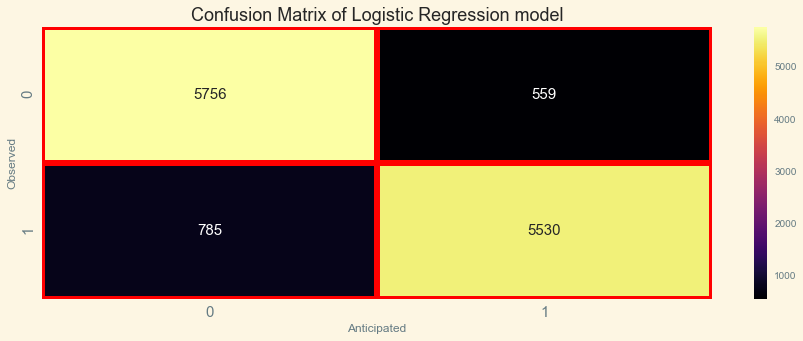

```
----------------------------------------
True Negative: 5756
False Positive: 785
False Negative: 559
True Positive: 5530
Correct Predictions 89.36 %
----------------------------------------
The acuuracy of the model = TP+TN/(TP+TN+FP+FN) =  0.89
 The Missclassification = 1-Accuracy =  0.11
 Sensitivity or True Positive Rate = TP/(TP+FN) =  0.91
 Specificity or True Negative Rate = TN/(TN+FP) =  0.88
 Positive Predictive value = TP/(TP+FP) =  0.88
 Negative predictive Value = TN/(TN+FN) =  0.91
 Positive Likelihood Ratio = Sensitivity/(1-Specificity) =  7.57
 Negative likelihood Ratio = (1-Sensitivity)/Specificity =  0.1
```

```python
#Confusion matrix visualization
plt.figure(figsize=(15,5))
confusion_matrix = pd.crosstab(y_test,
                               predictions_model_test,
                               rownames=["Observed"],
                               colnames=["Anticipated"])
sns.heatmap(confusion_matrix,
            annot=True,
            fmt = "d",
            annot_kws={"fontsize" : 15},
            cmap="inferno",
            linewidth = 5,
            linecolor="red")
plt.xticks(fontsize=15)
plt.yticks(fontsize=15)
plt.title("Confusion Matrix of Logistic Regression model", fontsize= 18)
plt.show()

print("-"*40)

TN = confusion_matrix[0][0]
FP = confusion_matrix[0][1]
FN = confusion_matrix[1][0]
TP = confusion_matrix[1][1]
sensitivity=TP/float(TP+FN)
specificity=TN/float(TN+FP)

print("True Negative:", TN)
print("False Positive:", FP)
print("False Negative:", FN)
print("True Positive:", TP)
print("Correct Predictions", round((TN + TP) / len(predictions_model_test) * 100, 2), "%")

print("-"*40)

print("The acuuracy of the model = TP+TN/(TP+TN+FP+FN) = ",round((TP+TN)/float(TP+TN+FP+FN),2),"\n",
"The Missclassification = 1-Accuracy = ",round(1-((TP+TN)/float(TP+TN+FP+FN)),2),"\n",
"Sensitivity or True Positive Rate = TP/(TP+FN) = ",round(TP/float(TP+FN),2),"\n",
"Specificity or True Negative Rate = TN/(TN+FP) = ",round(TN/float(TN+FP),2),"\n",
"Positive Predictive value = TP/(TP+FP) = ",round(TP/float(TP+FP),2),"\n",
"Negative predictive Value = TN/(TN+FN) = ",round(TN/float(TN+FN),2),"\n",
"Positive Likelihood Ratio = Sensitivity/(1-Specificity) = ",round(sensitivity/(1-specificity),2),"\n",
"Negative likelihood Ratio = (1-Sensitivity)/Specificity = ", round((1-sensitivity)/specificity,2))
```

### 9.2.2 ROC curve

Receiver Operating Characteristic — illustrates the relationship between the percentage of true positive results (sensitivity) and the percentage of false positive results (inverse specificity).  
Graph should be convex to the left upper corner. The more accurate the model, the more the curve is shifted left and up. The diagonal represents a classifier generating random results. Field under the curve is an indicator describing the efficiency of the model.

ROC curve has similar shape on test and train dataset. It means that probably there is no overfitting. Result is really good, so there is also no underfitting. Rest indicators concerning test and train datasets will be compared later to make sure that there is no over/underfitting.

```python
#Function to plot ROC - used to plot ROC curve in model 2 and model 3
def roc_plot(model, x_test_or_train_dataset, y_test_or_train_dataset, kind_dataset):
    """
    Building ROC curve based on arguments: model, x from test or train dataset, y from test or train
    dataset, kind of dataset: test or train.
    """
    y_pred_proba = model.predict_proba(x_test_or_train_dataset)[::,1]
    fpr, tpr, _ = metrics.roc_curve(y_test_or_train_dataset, y_pred_proba)
    auc = metrics.roc_auc_score(y_test_or_train_dataset, y_pred_proba)
    plt.plot(fpr, tpr, label="Logistic Regression (auc = %0.2f)" % auc, color="black")
    plt.xlabel("False Positive Rate",color="grey", fontsize = 18)
    plt.ylabel("True Positive Rate",color="grey", fontsize = 18)
    #Condition for kind of dataset
    if kind_dataset == "test":
        plt.title("Test dataset - ROC", fontsize=25)
    elif kind_dataset == "train":
        plt.title("Train dataset - ROC", fontsize=25)
    #Setting legend
    plt.legend(loc=4,
               fontsize=15,
               prop={"size": 14},
               title="Area Under Curve",
               title_fontsize="16",
               frameon=True)
    plt.plot([0, 1], [0, 1],"r--")
```

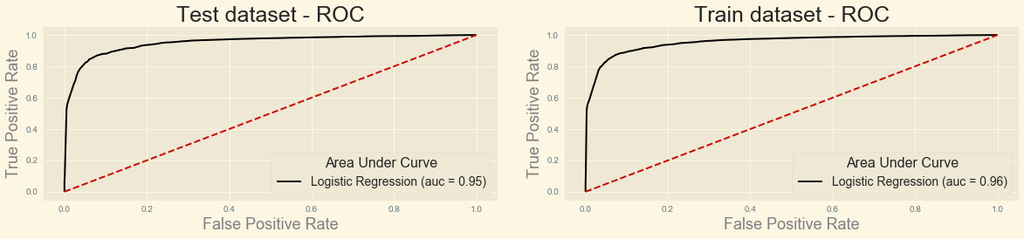

```python
#ROC curves plots for test and train dataset. Activation of built function: roc_plot
plt.figure(figsize=(20,8))
plt.subplots_adjust(left=None, bottom=None, right=None, top=None, wspace=0.15, hspace=None)

plt.subplot(2,2,1)
#Activation of built function
roc_plot(logistic_regression, X_test, y_test, kind_dataset="test")

plt.subplot(2,2,2)
#Activation of built function
roc_plot(logistic_regression, X_train, y_train, kind_dataset="train")

plt.show()
```

### 9.2.3 AUC

Area under ROC curve is 0.95, which is a very good result and illustrates high efficiency of the model.

```python
#Calculation of area under the ROC curve
y_pred_proba = logistic_regression.predict_proba(X_test)[::,1]
AUC = round(roc_auc_score(y_test, y_pred_proba),2)
print("AUC (Area under the curve) is:", AUC)
```

```
AUC (Area under the curve) is: 0.95
```

### 9.2.4 Accumulative protif curve

The binary classifier can be evaluated using the accumulated profit curve, which illustrates the relationship between the percentage of true positive results (sensitivity) and the percentage of positive forecasts. The purpose of this curve is to sort all classifications according to the predicted probability. On the horizontal axis there is a percentage of the forecast positive results. Vertical axis represents sensitivity (percentage of results truly positive).

If we rank clients according to their probability of buy deposit and select those whose chances are no more than 20%, it will turn out that this is 40% of all clients.

- chances of buy deposit by client no greater than 20% -----> 40% of clients
- chances of buy deposit by client no greater than 40% -----> 75% of clients
- chances of buy deposit by client no greater than 60% -----> 95% of clients

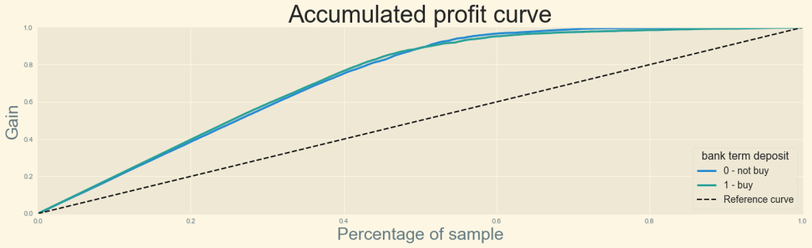

```python
#Accumulated profit curve
fig, ax = plt.subplots(figsize=(20, 5))
y_probas = logistic_regression.predict_proba(X_test)
skplt.metrics.plot_cumulative_gain(y_test,
                                   y_probas,
                                   ax=ax)
ax.set_title("Accumulated profit curve", fontsize=35)
ax.set_xlabel("Percentage of sample", fontsize=25)
ax.set_ylabel("Gain", fontsize=25)
#Setting legend
ax.legend(("0 - not buy",
           "1 - buy",
           "Reference curve"),
           frameon=True,
           loc="lower right",
           title="bank term deposit",
           title_fontsize = "16",
           prop={"size": 14})

plt.show()
```

### 9.2.5 Forecasting error of classes

Class forecasting error - the upper part of the left bar represents the number of clients who did not buy term deposit, but were expected to buy (false positive), the lower part of the right-hand bar represents the number the buying clients, however, were expected to not buy (result falsely negative).

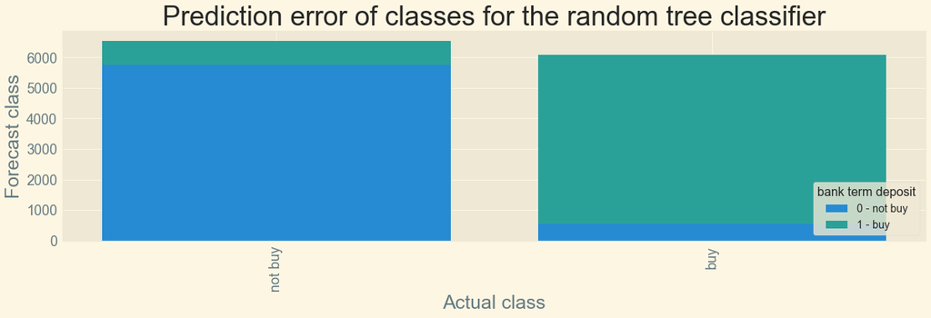

```python
#Forecasting error of classes
fig, ax = plt.subplots(figsize=(20, 5))
cpe_viz = ClassPredictionError(logistic_regression,
                               classes=["not buy", "buy"])
cpe_viz.score(X_test, y_test)
ax.set_xticks(np.arange(len(cpe_viz.classes)))
ax.set_xticklabels(cpe_viz.classes, fontsize=18)
ax.set_yticklabels(range(0,7000,1000),fontsize=18)
ax.set_xlabel("Actual class", fontsize=25)
ax.set_ylabel("Forecast class", fontsize=25)
ax.set_title("Prediction error of classes for the random tree classifier", fontsize=35)
#Setting legend
ax.legend(("0 - not buy",
           "1 - buy"),
           frameon=True,
           loc="lower right",
           title="bank term deposit",
           title_fontsize = "16",
           prop={"size": 14})

plt.show()
```

### 9.2.6 Classifivation report

- **accuracy** - Percentage of correct forecasts.
- **precision** - Ability to find only the right samples. Percentage of correct positive forecasts (PP divided by [PP + FP]). (How accurate are the results?).
- **recall** - Ability to search only positive samples. percentage of positively classified positive results. (How many successful results were returned?).
- **f1** - Harmonic average of precision and sensitivity.

```python
#Model evaluation by standard classification report
print(classification_report(y_test, predictions_model_test))
```

```
              precision    recall  f1-score   support

           0       0.88      0.91      0.90      6315
           1       0.91      0.88      0.89      6315

    accuracy                           0.89     12630
   macro avg       0.89      0.89      0.89     12630
weighted avg       0.89      0.89      0.89     12630
```

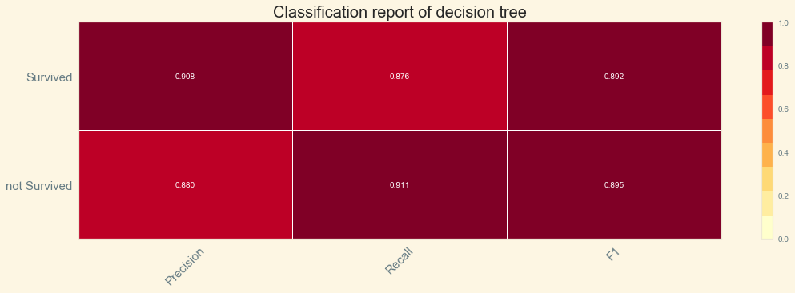

```
----------------------------------------
Indicators:

Accuracy: 0.89
--------------------
Recall: 0.88
--------------------
Precision: 0.91
--------------------
F1: 0.89
```

```python
#Classification report and indicators: accuracy, recall, precision, f1
fig, ax = plt.subplots(figsize=(18, 5))
cm_viz = ClassificationReport(logistic_regression,
                              classes=["not Survived", "Survived"],
                              annot_kws={"fontsize" : 30})
cm_viz.score(round(X_test,2), y_test)
cm_viz.ax.set_title("Classification report of decision tree", fontsize=20)
xlabels = ("Precision", "Recall", "F1")
ax.set_xticks(np.arange(len(xlabels)) + 0.5)
ax.set_xticklabels(xlabels, rotation=45, fontsize=15)
ax.set_yticks(np.arange(len(cm_viz.classes)) + 0.5)
ax.set_yticklabels(cm_viz.classes, fontsize=15)

plt.show()

print("-"*40)

print("Indicators:")
print("")
#Accuracy
from sklearn.metrics import accuracy_score
accuracy_model_2 = round(accuracy_score(y_test, predictions_model_test),2)
print("Accuracy: %0.2f" % (accuracy_model_2))
print("-"*20)
#Recall
from sklearn.metrics import recall_score
recall_model_2 = round(recall_score(y_test, predictions_model_test),2)
print("Recall: %0.2f" % (recall_model_2))
print("-"*20)
#Precision
from sklearn.metrics import precision_score
precision_model_2 = round(precision_score(y_test, predictions_model_test),2)
print("Precision: %0.2f" % (precision_model_2))
print("-"*20)
#F1
from sklearn.metrics import f1_score
f1_model_2 = round(f1_score(y_test, predictions_model_test),2)
print("F1: %0.2f" % (f1_model_2))
```

# 10. Comparison of results on test and train datasets - overfitting/underfitting detection

```python
#Calculation of statistics of train dataset
y_pred_proba_train = logistic_regression.predict_proba(X_train)[::,1]

AUC_train = round(roc_auc_score(y_train, y_pred_proba_train),2)
accuracy_train = round(accuracy_score(y_train, predictions_model_train),2)
recall_train = round(recall_score(y_train, predictions_model_train),2)
precision_train = round(precision_score(y_train, predictions_model_train),2)
f1_train = round(f1_score(y_train, predictions_model_train),2)

#Statistics of test dataset (calculated earlier)
AUC_test = AUC
Accuracy_test = accuracy_model_2
Recall_test = recall_model_2
Precision_test = precision_model_2
F1_test = f1_model_2

#Statistics of train dataset
AUC_train = AUC_train
Accuracy_train = accuracy_train
Recall_train = recall_train
Precision_train = precision_train
F1_train = f1_train
```

```python
#Data Frame with comparison of results on test and train datasets
comparison_test_train =pd.DataFrame({"dataset"   : ["test", "train"],
                                     "AUC"       : [AUC_test, AUC_train],
                                     "Accuracy"  : [Accuracy_test, Accuracy_train],
                                     "Recall"    : [Recall_test, Recall_train],
                                     "Precision" : [Precision_test, Precision_train],
                                     "F1"        : [F1_test, F1_train]}).set_index("dataset")
comparison_test_train
```

| dataset | AUC | Accuracy | Recall | Precision | F1 |
| --- | --- | --- | --- | --- | --- |
| test | 0.95 | 0.89 | 0.88 | 0.91 | 0.89 |
| train | 0.96 | 0.90 | 0.88 | 0.92 | 0.90 |

Results in both datasets (test and training) are comparable, so there is no overfitting. Furthermore, results are also not really low, so there is no underfitting of the model.

# 11. Model interpretation

```python
#Coefficients of the second model
print(logistic_regression.coef_[0])
```

```
[-3.68345109 -2.82906995 -3.40506764 -3.4884843  -2.59933915 -2.65346009
 -2.31931028 -2.76331461 -3.33918468 -2.2947296  -3.00808843 -2.53384477
 -2.1528211  -1.79993547  4.59635432 -2.54349167 -2.18124459 -2.36208204
 -2.32167469  2.4735566 ]
```

```python
#The list of selected data used to build model
selected_data
```

```
['job_blue-collar',
 'job_entrepreneur',
 'job_housemaid',
 'job_retired',
 'job_self-employed',
 'job_services',
 'job_unemployed',
 'education_high.school',
 'education_professional.course',
 'education_university.degree',
 'education_unknown',
 'contact_telephone',
 'month_aug',
 'month_nov',
 'month_oct',
 'day_of_week_mon',
 'day_of_week_thu',
 'day_of_week_tue',
 'day_of_week_wed',
 'poutcome_success']
```

The coefficients in logistic regression are not interpretable. Only one can deduce their signs - negative - negatively affect on probability, positive - positively affect on probability.

# 12. Results export to Excel

```python
#Prediction on the test dataset
probability_prediction=logistic_regression.predict_proba(X_test)[:,:]*100
probability_prediction=pd.DataFrame(data=probability_prediction,
                                    columns=["Probability of not buy deposit (0)", "Probability of buy deposit (1)"])
probability_prediction.head(5).round(2)
```

|  | Probability of not buy deposit (0) | Probability of buy deposit (1) |
| --- | --- | --- |
| 0 | 1.58 | 98.42 |
| 1 | 88.95 | 11.05 |
| 2 | 0.14 | 99.86 |
| 3 | 97.76 | 2.24 |
| 4 | 1.58 | 98.42 |

```python
#Join prediction to the base dataset
observed_predicted_target = os_data_y.join(probability_prediction).round(2)
observed_predicted_target[["y",
                           "Probability of not buy deposit (0)",
                           "Probability of buy deposit (1)"]].head(10)
```

|  | y | Probability of not buy deposit (0) | Probability of buy deposit (1) |
| --- | --- | --- | --- |
| 0 | 0 | 1.58 | 98.42 |
| 1 | 0 | 88.95 | 11.05 |
| 2 | 0 | 0.14 | 99.86 |
| 3 | 0 | 97.76 | 2.24 |
| 4 | 0 | 1.58 | 98.42 |
| 5 | 0 | 13.74 | 86.26 |
| 6 | 0 | 1.58 | 98.42 |
| 7 | 1 | 97.54 | 2.46 |
| 8 | 0 | 69.91 | 30.09 |
| 9 | 0 | 1.58 | 98.42 |

```python
#Select columns to export
results_to_export = observed_predicted_target[["y",
                                               "Probability of not buy deposit (0)",
                                               "Probability of buy deposit (1)"]]
```

```python
#Export results to Excel
results_to_export.to_excel("Predictions.xlsx",
                           index=False,
                           header=True)
```

# 13. Conclusions

**General summary**

The main target of this project was to build and evaluate classification model to predict whether the client will subscribe to a term deposit. Logistic Regression model was used to perform the prediction.  
Data was explored and visualized. Moreover, analysis of normal distiburion, outliers removal, dummy coding, oversampling by SMOTE and features selection by RFE were performed. Then selected variables were evaluate based on p-value and VIF and model was build and evaluated.

**EDA (Exploratory Data Analysis) summary**

Dataset contains 41188 observations as well as 21 variables including target variable (y). After outliers removal the dataset has 32050 observations and 21 features.  
The dataset does not contain missing variables.  
Data was cleaned and then grouped and visualized. Data was also explore in terms of model suitability based on the variability of values in variable.

**Modelling summary**

After analysis of normal distiburion, outliers removal, dummy coding, oversampling by SMOTE and features selection by RFE selected features were evaluated based on p-value and VIF indicator. All selected values were finally used in model biulding.  
The dataset was splitted by train (70%) and test (30%) dataset. Furtermore, stratify parameter was used to the target variable was presented in proportion to the main dataseet.  
Model was evaluated by: Confusion Matrix, ROC curve, AUC, Accumulative protif curve, Forecasting error of classes, Classification Report and indicators: Accuracy, Recall, Precision, F1  
Results of train and test datasets were compared. In this way was confirmed that there is no overfitting or underfitting.  
Model presents really good results with for instance Accuracy = 0.89.